# Assignment 3: U.S. Senators on Twitter

#### b) Communities

Now let’s see whether party identification is also recovered by an automated mechanism of cluster identification. Use the `cluster_walktrap` command in the `igraph` package to find densely connected subgraphs.

```r
ell <- true_follow
rt_graphh <- graph_from_data_frame(d=ell, directed=T)

wcc <- cluster_walktrap(rt_graphh)
memberss <- membership(wcc)
d3_rtt <- igraph_to_networkD3(rt_graphh, group = memberss)
set.seed(1009)
plot(simplify(rt_graphh), group = memberss, vertex.color=memberss)

#The function was able to adequately separate the two parties
```

[output not shown]

Based on the results, visualize how well this automated community detection mechanism recovers the party affiliation of senators. This visualization need not be a network graph. Comment briefly.

### 2. What are they tweeting about?

From now on, rely on the information from the tweets stored in `senator_tweets.RDS`.

#### a) Most Common Topics over Time

Remove all tweets that are re-tweets (`is_retweet`) and identify which topics the senators tweet about. Rather than a full text analysis, just use the variable `hashtags` and identify the most common hashtags over time. Provide a visual summary.

```r
senator_tweets <- readRDS("senator_tweets.RDS")

# How limiting is the API limit?
senator_tweets %>%
  group_by(screen_name) %>%
  summarize(n_tweet = n(),
            oldest_tweet = min(created_at)) %>%
  arrange(desc(oldest_tweet))
```

```
## # A tibble: 100 x 3
##    screen_name    n_tweet oldest_tweet
##    <chr>            <int> <dttm>
##  1 SenDougJones       178 2018-01-05 18:18:46
##  2 SenTinaSmith       814 2018-01-03 16:21:07
##  3 JohnCornyn        3193 2017-05-31 02:56:50
##  4 SenWhitehouse     3206 2017-05-08 18:44:06
##  5 senorrinhatch     3212 2017-05-01 14:36:04
##  6 brianschatz       3211 2017-04-23 21:15:28
##  7 senrobportman     3237 2017-04-19 15:39:38
##  8 SenMarkey         3241 2017-03-21 18:44:15
##  9 CoryBooker        3206 2017-03-09 21:57:18
## 10 SenJeffMerkley    3248 2017-03-07 01:40:21
## # ... with 90 more rows
```

```r
noret <- senator_tweets[senator_tweets$is_retweet == "FALSE",]
noretweet <- senator_tweets[senator_tweets$is_retweet == "FALSE",]
noret$created_at <- substr(noret$created_at, 1, 7)

allhash <- unnest(noret, hashtags)
```

```r
allhash <- allhash[order(allhash$created_at),]
newhash <- tail(allhash, -7680)

tabl <- as.data.frame(table(newhash$hashtags, newhash$created_at))
colnames(tabl) <- c('Hashtag', 'Date', 'Count')
tabl <- tail(tabl, -2)
tabl <- tabl[order(tabl$Date),]
tabb <- table(newhash$hashtags)

headhash <- allhash[newhash$hashnum > 1,]
```

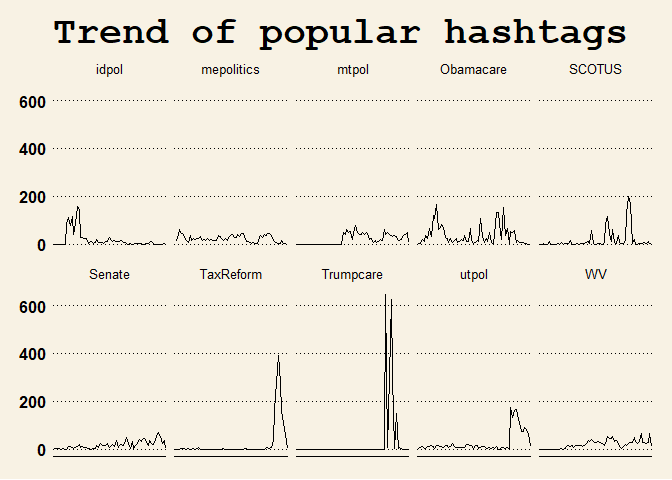

```r
poph <- as.data.frame(head(sort(tabb, decreasing = TRUE), 10))


p5 <- ggplot(tabl[tabl$Hashtag %in% poph$Var1,], aes(x = Date, y = Count, group=1))

(p5 <- p5 + geom_line() +
   facet_wrap(~Hashtag, ncol = 5)) + theme_wsj() +
  theme(axis.title.x=element_blank(),
        axis.text.x=element_blank(),
        axis.ticks.x=element_blank()) + ggtitle("Trend of popular hashtags")
```

```r
#These show the trends for different hashtags since 2013, when hashtags became more widely used
```

#### b) Democrats vs. Republicans

Some tweets are as old as 10 years but for some prolific users we observe a much shorter time span of Twitter activity. Feel free to subset the data to only include more recent tweets. Using the party ID variable (`Party affiliation`), identify how the choice of topics tweeted about (again using using hashtags) differs by party and visualize that information.

```r
newhashwp <- merge(x = newhash, y = seninfo[ , c("Official.Twitter","Party.affiliation")], by.x = "screen_name", by.y = "Official.Twitter", all.x=TRUE)

tabl2 <- as.data.frame(table(newhashwp$hashtags, newhashwp$Party.affiliation))
tabl2 <- tail(tabl2, -2)
colnames(tabl2) <- c('Hashtag', 'Party', 'Count')
```

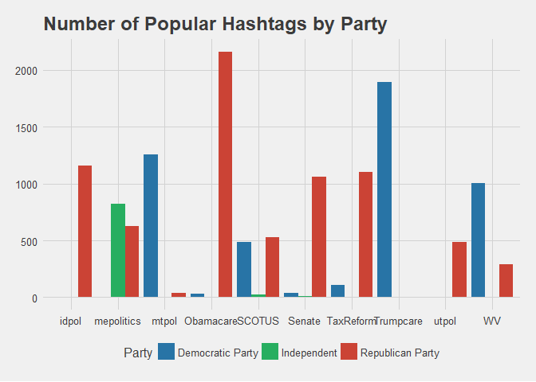

```r
ggplot(tabl2[tabl2$Hashtag %in% poph$Var1,],aes(x=Hashtag,y=Count,fill=Party))+
  geom_bar(stat="identity",position="dodge")+ theme(axis.text.x = element_text(angle = 90, hjust = 1))+ scale_fill_manual(values=c("#2874A6", "#27AE60", "#CB4335")) + ggtitle("Number of Popular Hashtags by Party")+
  theme_fivethirtyeight()
```

```r
#popular tags by party since 2013
```

#### c) Gun Control I - Dems vs. Reps

The democratic party seems broadly more supportive of gun control legislation. Try to identify a set of 5-10 hashtags that signal support for gun control legislation (e.g. “`NeverAgain`”, `#guncontrol`, `#guncontrolnow`, `#Enough`) and others that are expressing support for the right to own guns (e.g. `#2ndamendment`, `#NRA`, `#liberals`). The site [ritetag.com](https://ritetag.com/best-hashtags-for/gun%20control) can help with that task. Using the subset of senator tweets that included these hashtags, show whether and how senators from different parties talk differently about the issue of gun legislation.

```r
nogun <- c("NeverAgain", "guncontrol", "guncontrolnow", "Enough", "gunviolence", "gunsense", "GunReformNow",
           "BoycottNRA","guncontrolsaveslives", "firearmsafety", "FireArmSafety", "MarchForOurLives", "GunControl", "GunViolence",
           "NotOneMore", "GunSafety", "gunsafety", "GunSense")
yesgun <- c("2ndamendment", "NRA", "liberals", "2ndAmendment", "2ndamdt", "2ndAmdt","2ndamendent", "2A", "ArmedCitizen", "GunRights",
            "gunrights", "firearms", "nra", "armedcitizen", "IAmTheNRA", "Freedom", "AR15", "DefendTheSecond", "GunOwner", "GunsSaveLives", "ProGun", "SelfDefense", "progun", "freedom", "defendthesecond", "gunssavelives")


sum(tabl2$Party == "Democratic Party" &  tabl2$Hashtag %in% nogun)
```

```
## [1] 13
```

```r
sum(tabl2$Party == "Democratic Party" &  tabl2$Hashtag %in% yesgun)
```

```
## [1] 12
```

```r
sum(tabl2$Party == "Republican Party" &  tabl2$Hashtag %in% nogun)
```

```
## [1] 13
```

```r
sum(tabl2$Party == "Republican Party" &  tabl2$Hashtag %in% yesgun)
```

```
## [1] 12
```

```r
sum(tabl2$Party == "Independent" &  tabl2$Hashtag %in% nogun)
```

```
## [1] 13
```

```r
sum(tabl2$Party == "Independent" &  tabl2$Hashtag %in% yesgun)
```

```
## [1] 12
```

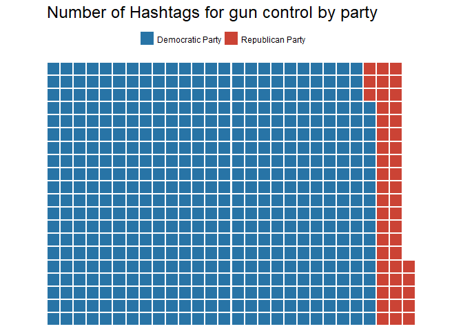

```r
noguntab <- tabl2[tabl2$Hashtag %in% nogun,]
yesguntab<- tabl2[tabl2$Hashtag %in% yesgun,]
nogunrep <- noguntab[noguntab$Party == "Republican Party",]
nogundem <- noguntab[noguntab$Party == "Democratic Party",]
yesgundem <- yesguntab[yesguntab$Party == "Democratic Party",]
yesgunrep <- yesguntab[yesguntab$Party == "Republican Party",]

nnr <- sum(nogunrep$Count)
nnd <- sum(nogundem$Count)
nyd <- sum(yesgundem$Count)
nyr <- sum(yesgunrep$Count)


nos <- c(nnd, nnr)
names(nos) <- c("Democratic Party", "Republican Party")

yess <- c(nyd, nyr)
names(yess) <- c("Democratic Party", "Republican Party")

waffle(nos, rows=20,size=1,legend_pos = "top",
       title="Number of Hashtags for gun control by party",
        colors=c("#2874A6", "#CB4335"))
```

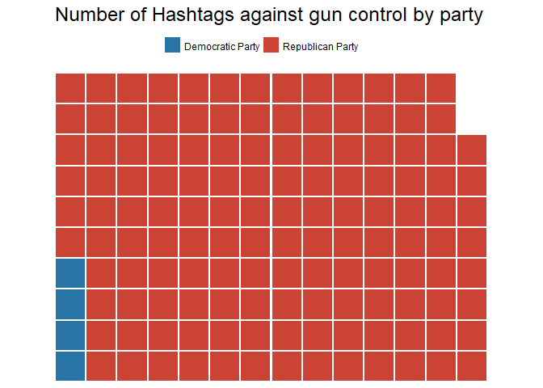

```r
waffle(yess, rows=10,size=1,legend_pos = "top",
       title="Number of Hashtags against gun control by party",
        colors=c("#2874A6", "#CB4335"))
```

```r
#Shows the distribution of each party members for gun control legislation
```

#### d) Gun Control II - Parkland Shooting

On February 14, 2018, a mass shooting occurred at Marjory Stoneman Douglas High School in Parkland, Florida. Provide some visualization of how senators responded to the event in their Twitter communication.

```r
parkland <- noretweet[substr(noretweet$created_at,1,10) == '2018-02-14',]
days <- noretweet
days$created_at <- substr(noretweet$created_at, 1, 10)
days <- unnest(days, hashtags)
```

[figure not shown]

```r
days <- days[substr(days$created_at,3,4) == '18',]
days <- days[substr(days$created_at,6,7) == '02',]
numdays <- as.data.frame(table(days$created_at))
tagdays <- as.data.frame(table(days$hashtags, days$created_at))

ggplot(numdays, aes(Var1, Freq)) + geom_line(aes(group=1)) + xlab("") + ylab("Number of Hashtags")+ theme_solarized()+theme(axis.text.x = element_text(angle = 90, hjust = 1))+ ggtitle("Number of Popular Hashtags by Month since 2013")
```

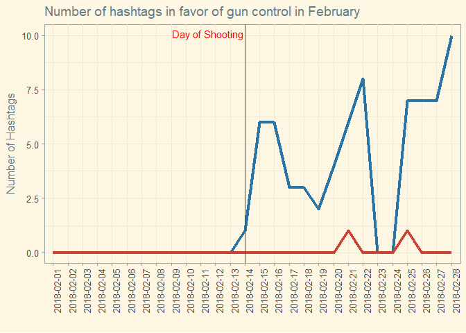

```r
nogundays <- tagdays[tagdays$Var1 %in% nogun,]
dta.sum <- aggregate(x = nogundays$Freq,
                     FUN = sum,
                     by = list(Group.date = nogundays$Var2))

yesgundays <- tagdays[tagdays$Var1 %in% yesgun,]
yessum <- aggregate(x = yesgundays$Freq,
                     FUN = sum,
                     by = list(Group.date = yesgundays$Var2))


ggplot() + geom_line(data=dta.sum, aes(Group.date, x),group=1, color='#2874A6', size=1.5) + geom_line(data=yessum, aes(Group.date, x),group=1, color = '#CB4335',size=1.5) + xlab("") + ylab("Number of Hashtags")+ theme_solarized()+theme(axis.text.x = element_text(angle = 90, hjust = 1))+ ggtitle("Number of hashtags in favor of gun control in February") + geom_vline(xintercept = 14, color = 'red')+ geom_text(data=data.frame(x=11.5,y=9.5), aes(x, y), label='Day of Shooting', vjust=-1, color='red')
```

```r
#The number of popular hashtags does not seem to have been affcted greatly, but hashtags for gun control increased.
```

### 3. Are you talking to me?

Often tweets are simply public statements without addressing a specific audience. However, it is possible to interact with a specific person by adding them as a friend, becoming their follower, re-tweeting their messages, and/or mentioning them in a tweet using the `@` symbol.

#### a) Identifying Re-Tweets

Select the set of re-tweeted messages from other senators and identify the source of the originating message. Calculate by senator the amount of re-tweets they received and from which party these re-tweets came. Essentially, I would like to visualize whether senators largely re-tweet their own party colleagues’ messages or whether there are some senators that get re-tweeted on both sides of the aisle. Visualize the result.

```r
retweets <- senator_tweets[senator_tweets$is_retweet == TRUE,]


#get IDs of those who got retweeted
retweets$from <-substring(gsub(":.*","",retweets$text),5)

ret_sen <- retweets[retweets$from %in% retweets$screen_name,]

newretsen <- merge(x = ret_sen, y = seninfo[ , c("Official.Twitter","Party.affiliation")], by.x = "screen_name", by.y = "Official.Twitter", all.x=TRUE)

names(newretsen)[names(newretsen) == 'Party.affiliation'] <- "Party"

newretsen <- merge(x = newretsen, y = seninfo[ , c("Official.Twitter","Party.affiliation")], by.x = "from", by.y = "Official.Twitter", all.x=TRUE, all.y=TRUE)
names(newretsen)[names(newretsen) == 'Party.affiliation'] <- "retweet_Party"

el <- newretsen[,c("from","screen_name", "Party")]
rt_graph <- graph_from_data_frame(d=el, directed=T)
wc <- cluster_walktrap(rt_graph)
members <- membership(wc)
d3_rt <- igraph_to_networkD3(rt_graph, group = members)

d3_rt$nodes$group <- ifelse(d3_rt$nodes$name %in% seninfo$Official.Twitter[seninfo$Party.affiliation == "Democratic Party"],
                            1,2)

forceNetwork(Links = d3_rt$links, Nodes = d3_rt$nodes,
             Source = 'source', Target = 'target',
             NodeID = 'name', Group = 'group', colourScale = JS("d3.scaleOrdinal().domain([1,2]).range(['#2874A6', '#CB4335']);") )
```

[interactive chart not shown]

```r
#You can see the division between the parties. Each party tends to retweet more of their own party's tweets
```